# The following code snippets go over some of the fundamental features of FDSN-via-ObsPy

# Removing instrument response is also very very easy!

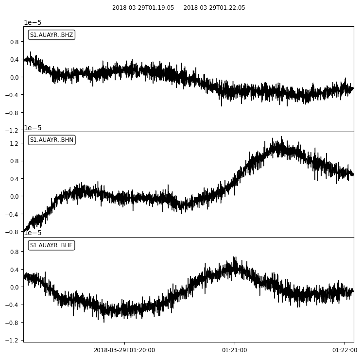

```python
#first, be sure that response information exists within our inventory. this is done by setting level='response'
inv = auspass.get_stations(network=network,level='response')
st.remove_response(inventory=inv) #this automatically parses the inventory for the correct network/station/channel response!
st.plot(); plt.show()
```

Response information can also be examined and even plotted

```
No handles with labels found to put in legend.
```

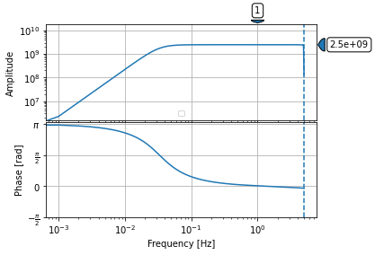

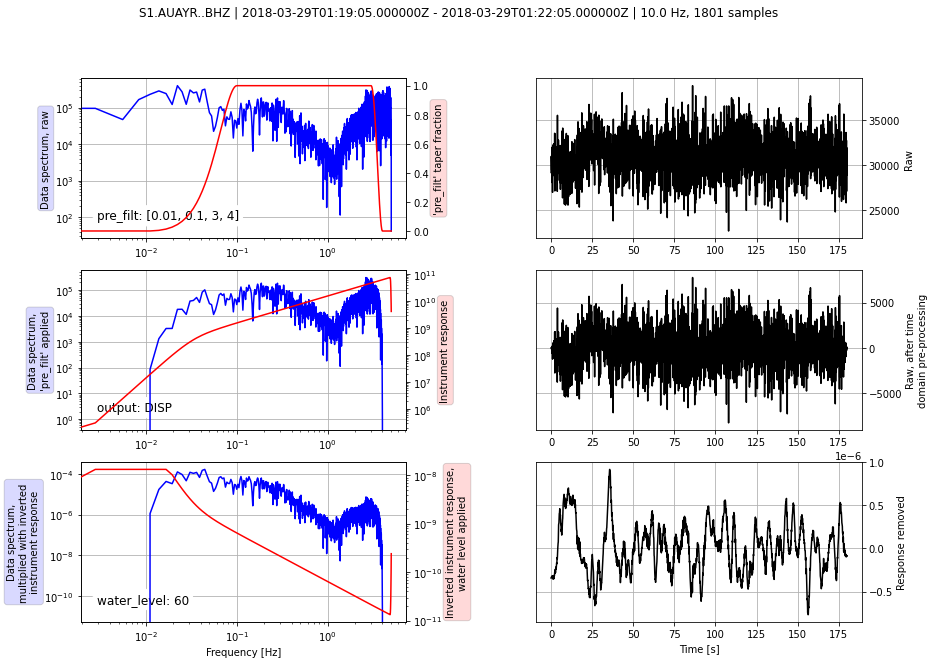

```python
#response is at the channel level (three subsets down) e.g. inv[network][station][channel]
inv0 = inv.select(network=network,station=station)
response = inv0[0][0][0].response
response.plot(min_freq=.001); plt.close()

#you can also directly compare the effect of removing the response on a waveform
st = st_bak.copy()
tr = st[0]
tr.remove_response(inventory=inv, output="DISP",pre_filt=[0.01,.1,3,4],water_level=60, plot=True); plt.show(); plt.close()
```

# Downloading EVENTS

- AusPass does not host independent earthquake information, but you can download it from many different agencies. See https://docs.obspy.org/packages/obspy.clients.fdsn.html

```
5 Event(s) in Catalog:
2016-01-31T17:38:59.950000Z | -63.263, +169.149 | 6.1 mww | manual
2016-01-26T03:10:20.750000Z |  -5.295, +153.245 | 6.1 mww | manual
2016-01-14T03:25:28.270000Z | -19.760,  -63.329 | 6.1 mww | manual
2016-01-05T09:34:14.620000Z | -54.291, -136.260 | 6.0 mww | manual
2016-01-01T02:00:39.950000Z | -50.557, +139.449 | 6.3 mww | manual
```

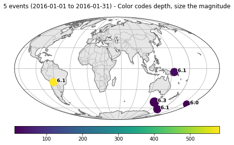

```python
#let's download earthquakes from USGS...

usgs = FDSN_Client("USGS") #establish connection in the same way as auspass. n.b."USGS" has its own shortcut, no address needed

#let's just download ALL earthquakes in the southern hemisphere during January 2016 greater than M6
events = usgs.get_events(starttime=obspy.UTCDateTime(2016,1,1), endtime=obspy.UTCDateTime(2016,2,1), maxlatitude=0, minmagnitude=6)

#show results & plot
print(events)
events.plot(); plt.close()
```

# Some other common operations...

```python
st.trim(starttime=time0,endtime=time1-5) #trims the last 5 seconds off all data in the stream

sub_st = st.slice(starttime=time0,endtime=time1-5) #returns a NEW stream "sub_st" instead, without altering original

st.decimate(factor=2) #performs a literal decimation bt "factor" amount (e.g. 100 Hz > 50 Hz)

##interpolate data to a set sampling rate (or via number or samples, or a time range, or...?
#Performs better than straight decimation when the factor is large)
st.interpolate(method='quadratic',sampling_rate=10)
```

```
3 Trace(s) in Stream:
S1.AUAYR..BHZ | 2018-03-29T01:19:05.000000Z - 2018-03-29T01:22:00.000000Z | 10.0 Hz, 1751 samples
S1.AUAYR..BHE | 2018-03-29T01:19:05.000000Z - 2018-03-29T01:22:00.000000Z | 10.0 Hz, 1751 samples
S1.AUAYR..BHN | 2018-03-29T01:19:05.000000Z - 2018-03-29T01:22:00.000000Z | 10.0 Hz, 1751 samples
```

- The waveform data contained in each trace is equivalent to a numpy array and all operations in numpy can be performed (e.g. calculating a mean or standard deviation)

```python
import numpy as np
tr = st[0]
std = np.std(tr.data)
mean = np.mean(tr.data)
```

- You may also want to change the data type (in numpy, "dtype") to a higher precision float, or to an integer. For encoding in Steim2, an int32 is required.

```python
#this loops through all traces in a stream and converts the data type
for tr in st: tr.data = tr.data.astype('int32') #or float64, or int8, or float16, or,..
```

# Metadata can also be called/printed/altered

- It is kept at the "trace" level under "stats"

```python
tr.stats #quickly prints what's available
sr = tr.stats.sampling_rate
delta = tr.stats.delta #the time in seconds per sample (e.g. 1/sr)
start = tr.stats.starttime + 10 #shifts starttime (as well as all subsequent time data) 10 seconds into the future
tr.stats.station = "NEWSTATIONNAME" #changes station name to whatever you like!
tr.stats.location = '00'
print("station name is now %s, and it now starts at %s" % (tr.stats.station,start))
```

```
station name is now NEWSTATIONNAME, and it now starts at 2018-03-29T01:19:15.000000Z
```

# Saving to disk

```python
#saves a local copy of inv as a 'STATIONXML', and validates it is structured correctly.
inv.write("S1.xml",format='STATIONXML',validate=True)

#lets save the events we downloaded as well
events.write("events.xml",format="QUAKEML")

#Saving miniseed data can be a little trickier, and you may have to organise filenames and data depending on what you're trying to do.
#To simply save the entire stream of data into a singular file,
st.write("filename.ms",format='MSEED',encoding='STEIM2',reclen=4096) #note that STEIM2 requires int32 dtype
```